# PetFinder Adoption Final Report

# Introduction

In 2016 alone there were over 2 million animals that ended up in animal shelters and were not adopted. Shelters around the world work constantly to attempt to lower this number and place deserving animals in loving homes. PetFinder, an animal adoption website, assists with this goal by allowing animal profiles to be put online for people to find. Getting a profile onto PetFinder is the first step, making an effective profile is more difficult. Questions of how many photos to include, how many videos? Should they list the vaccination status of the animal? These are just some questions that can arise during this process. We determined during our last study that when the adoption speed of an animal is numerical we were not able to successfully model this speed given these aspects of the profile using linear regression. So we decided to ask more complex questions about this dataset to see if we could determine patterns in adoption profiles that could give potential insight to adoption centers as they work to get animals adopted.

# Background EDA

We’re using the same dataset as from the midterm assignment. The data comes from Kaggle (https://www.kaggle.com/c/petfinder-adoption-prediction/data) and includs almost 15,000 observations of 23 variables. Each observation is an adoption profile on PetFinder in Malaysia. We chose to keep 9 features, as well as discarding any profile that contained more than one animal, and any animal that did not get adopted in the first 100 days. At the end of these cleaning measures we end up with 8485 observations of the 9 features. Initially we transformed the categorical dependent variable (adoption speed) into a continuous numerical variable. For the sake of this project we are keeping it as a categorical variable for some of our analyses.

As a refresher on the basic features of the dataset we can look at the distribution of the various variables.

First here is our dependent variable Adoption Speed, plotted by number of occurences since it is categorical.

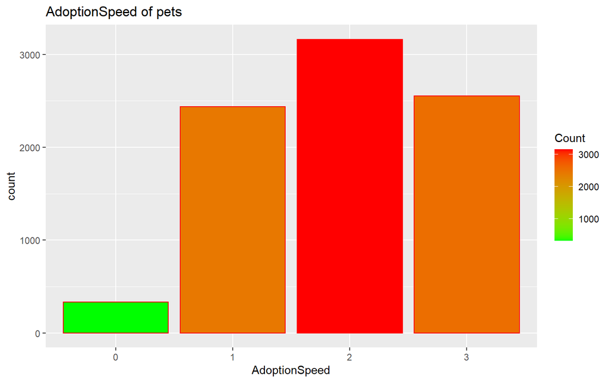

We can also look at the other numerical features.

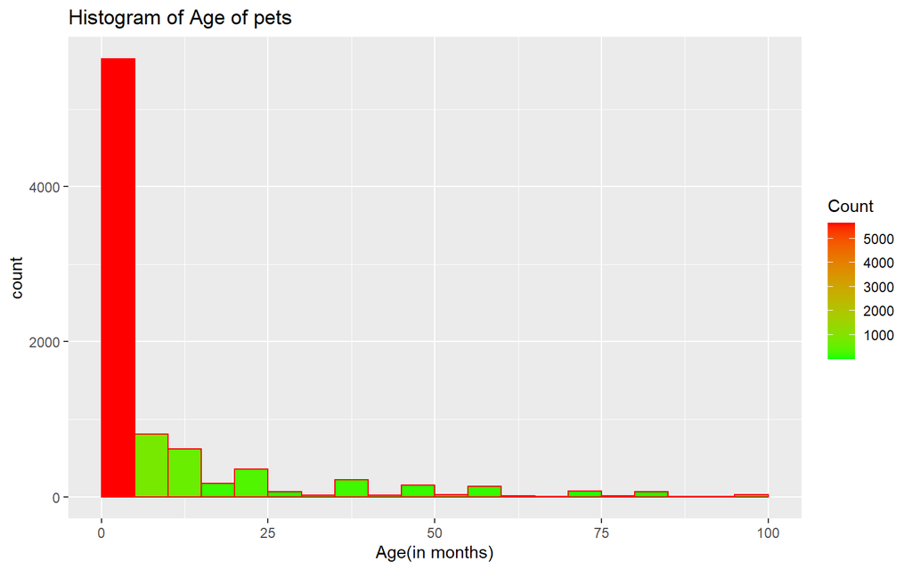

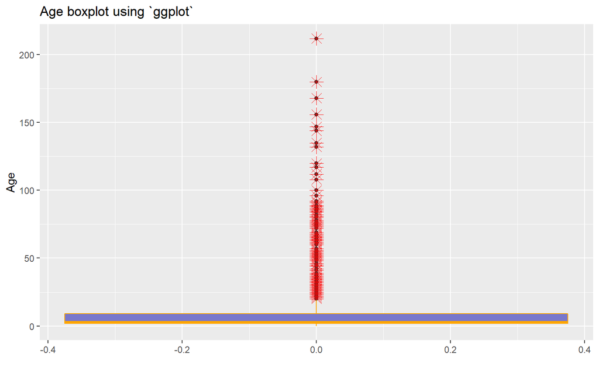

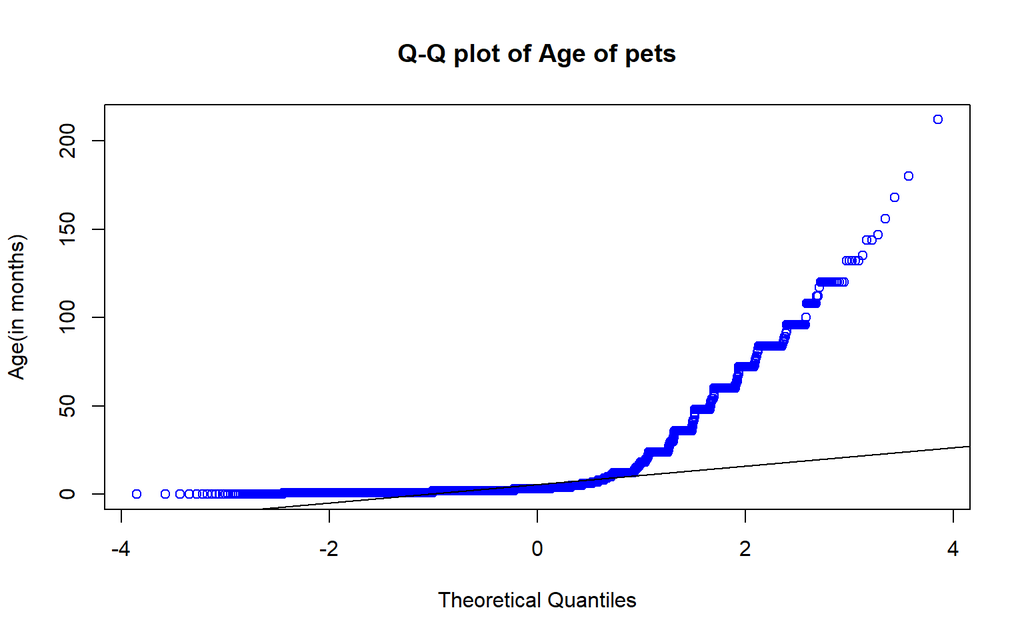

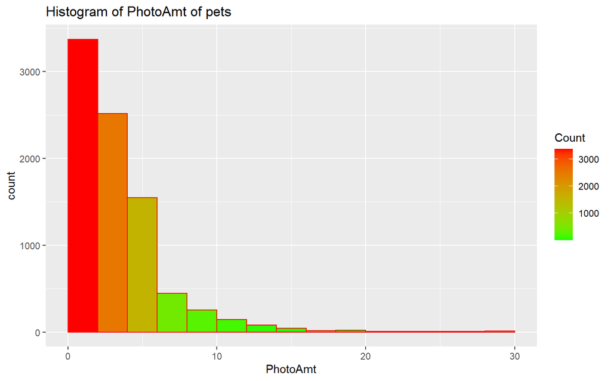

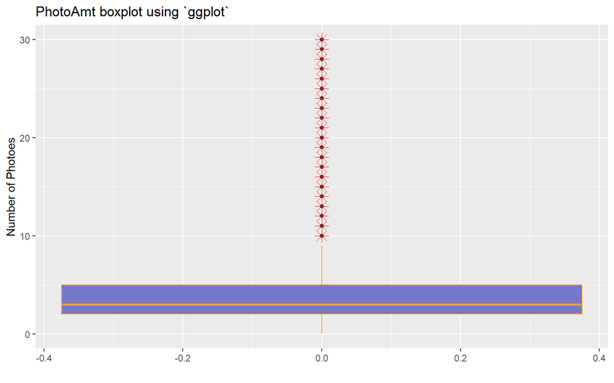

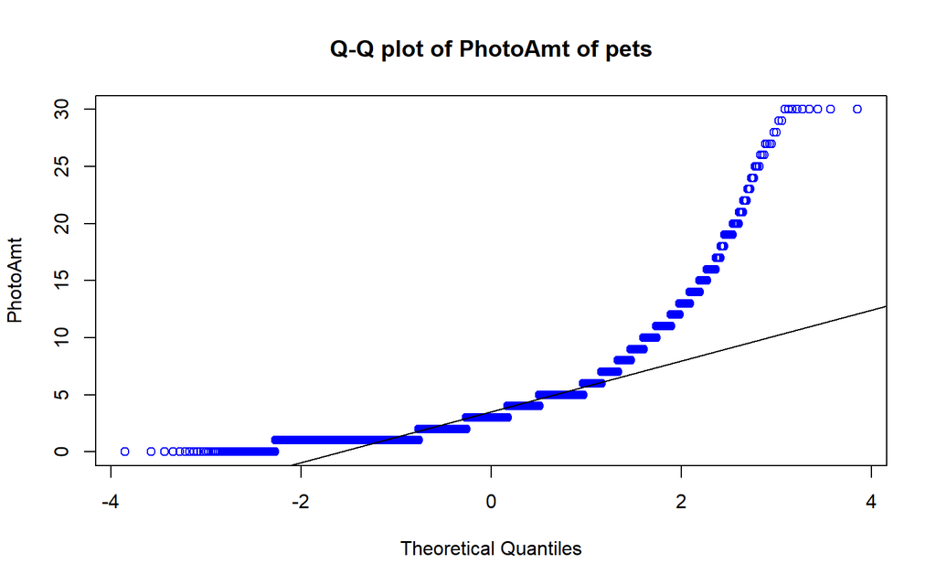

Next we can see the distributions of the categorical variables.

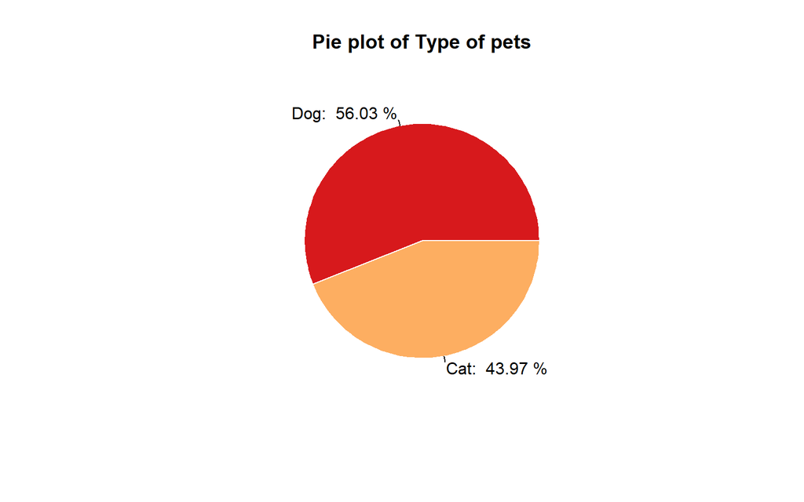

The second is `Gender`. There are two genders: `Male` and `Female`.

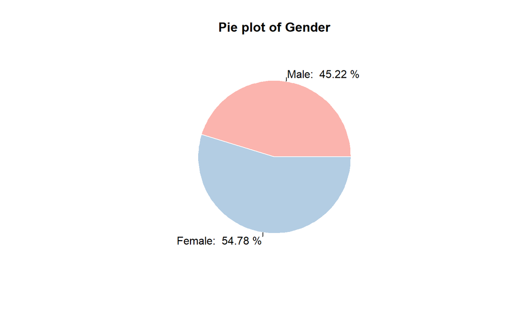

The third is `MaturitySize`. There are four levels, namely `Small`,`Medium`, `Large`, and `ExtraLarge`.

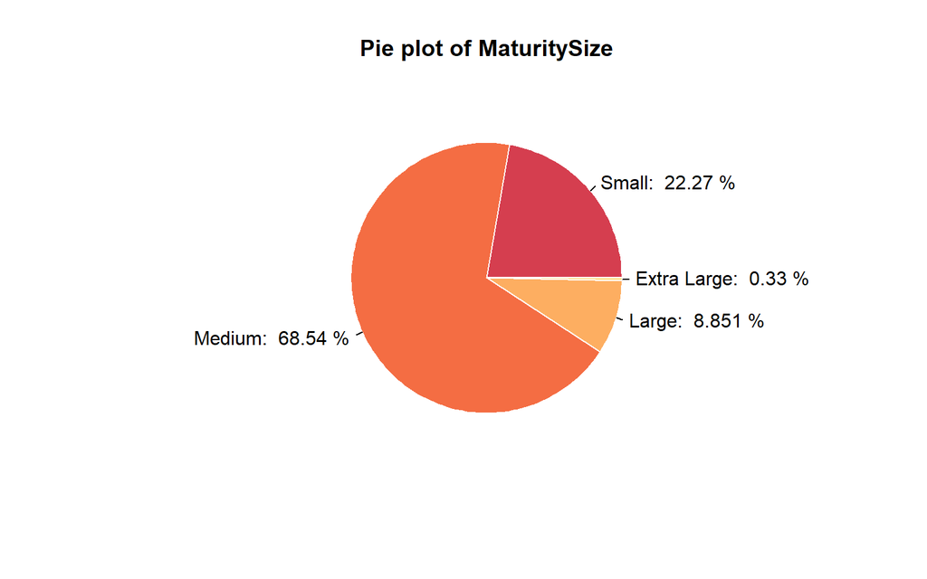

The fourth is `FurLength`. There are three levels, namely `Short`, `Medium`, and `Long`.

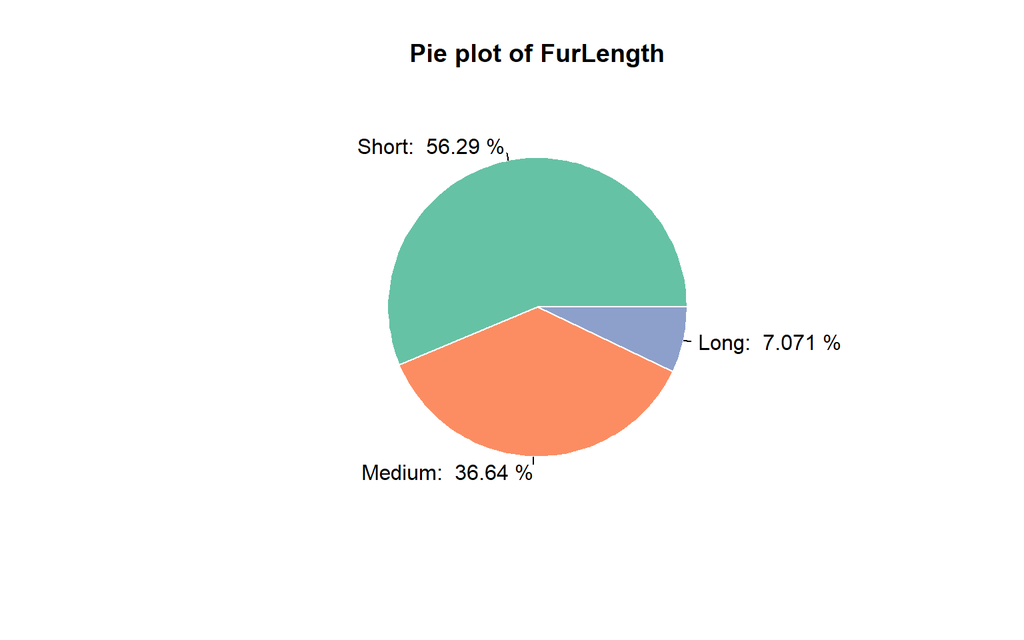

The fifth is `Vaccinated`. There are three levels, namely `Vaccinated`, `Unvaccinated`, and `Not Specified`.

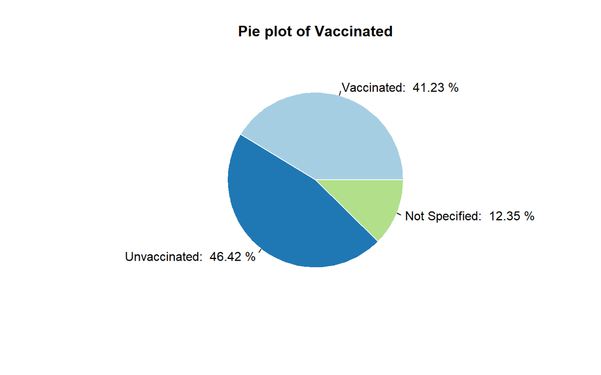

```
##
##  Welch Two Sample t-test
##
## data:  dogs$ASnum and cats$ASnum
## t = 9, df = 8211, p-value <2e-16
## alternative hypothesis: true difference in means is not equal to 0
## 95 percent confidence interval:
##  3.91 6.06
## sample estimates:
## mean of x mean of y
##      28.6      23.6
```

```
##
##  Welch Two Sample t-test
##
## data:  male$ASnum and female$ASnum
## t = -5, df = 8268, p-value = 5e-07
## alternative hypothesis: true difference in means is not equal to 0
## 95 percent confidence interval:
##  -3.87 -1.70
## sample estimates:
## mean of x mean of y
##      24.9      27.6
```

```
## Analysis of Variance Table
##
## Response: ASnum
##                Df  Sum Sq Mean Sq F value  Pr(>F)
## MaturitySize    3   46482   15494    24.2 1.3e-15 ***
## Residuals    8481 5426228     640
## ---
## Signif. codes:  0 '***' 0.001 '**' 0.01 '*' 0.05 '.' 0.1 ' ' 1
```

```
## Analysis of Variance Table
##
## Response: ASnum
##             Df  Sum Sq Mean Sq F value  Pr(>F)
## FurLength    2   24112   12056    18.8 7.4e-09 ***
## Residuals 8482 5448597     642
## ---
## Signif. codes:  0 '***' 0.001 '**' 0.01 '*' 0.05 '.' 0.1 ' ' 1
```

```
## Analysis of Variance Table
##
## Response: ASnum
##              Df  Sum Sq Mean Sq F value Pr(>F)
## Vaccinated    2   58767   29383      46 <2e-16 ***
## Residuals  8482 5413943     638
## ---
## Signif. codes:  0 '***' 0.001 '**' 0.01 '*' 0.05 '.' 0.1 ' ' 1
```

#SMART QUESTION: What is the probability that a large, female, vaccinated dog would get adopted quickly (adoption speed of 0 and 1).

Model: 4

Model: 3

Model: 2

Model: 1

Model: 0

|  | Type | Gender | MaturitySize | Vaccinated | AdoptionSpeed |
| --- | --- | --- | --- | --- | --- |
| X | 1:4754 | 1:3837 | 1:1890 | 1:3498 | 0: 331 |
| X.1 | 2:3731 | 2:4648 | 2:5816 | 2:3939 | 1:2439 |
| X.2 | NA | 3: 0 | 3: 751 | 3:1048 | 2:3163 |
| X.3 | NA | NA | 4: 28 | NA | 3:2552 |
| X.4 | NA | NA | NA | NA | 4: 0 |

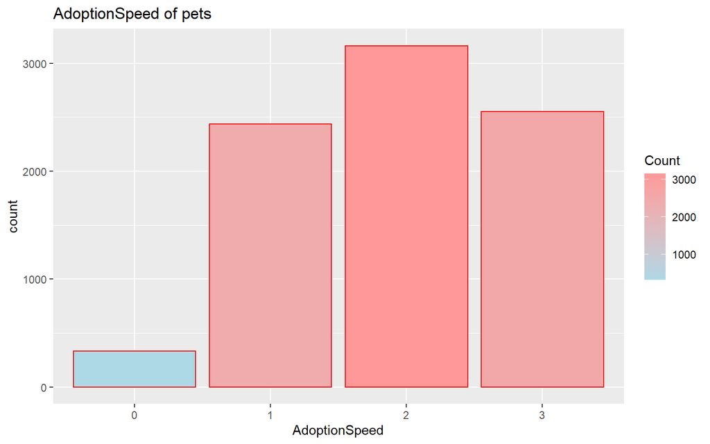

```
##  Type     Gender   MaturitySize Vaccinated AdoptionSpeed
##  1:4754   1:3837   1:1890       1:3498     0:2770
##  2:3731   2:4648   2:5816       2:3939     2:3163
##           3:   0   3: 751       3:1048     3:2552
##                    4:  28                  4:   0
```

```
##  Type     Gender   MaturitySize Vaccinated AdoptionSpeed
##  1:4754   1:3837   1:1890       1:3498     0:2770
##  2:3731   2:4648   2:5816       2:3939     2:3163
##           3:   0   3: 751       3:1048     3:2552
##                    4:  28
```

Model: NA

|  | Type | Gender | MaturitySize | Vaccinated | AdoptionSpeed |
| --- | --- | --- | --- | --- | --- |
| X | 1:4754 | 1:3837 | 1:1890 | 1:3498 | 0:2770 |
| X.1 | 2:3731 | 2:4648 | 2:5816 | 2:3939 | 2:5715 |
| X.2 | NA | 3: 0 | 3: 751 | 3:1048 | NA |
| X.3 | NA | NA | 4: 28 | NA | NA |

```
##  Type     Gender   MaturitySize Vaccinated AdoptionSpeed
##  1:4754   1:3837   1:1890       1:3498     0:2770
##  2:3731   2:4648   2:5816       2:3939     1:5715
##           3:   0   3: 751       3:1048
##                    4:  28
```

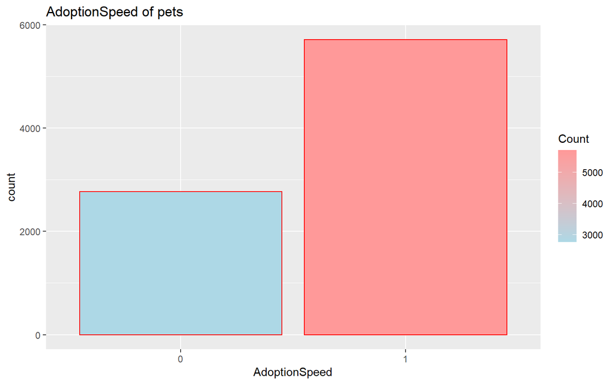

```
##
## Call:
## glm(formula = AdoptionSpeed ~ Type + MaturitySize + Vaccinated +
##     Gender, family = "binomial", data = new_dat)
##
## Deviance Residuals:
##    Min      1Q  Median      3Q     Max
## -1.737  -1.387   0.796   0.913   1.196
##
## Coefficients:
##               Estimate Std. Error z value Pr(>|z|)
## (Intercept)     0.6371     0.0680    9.37  < 2e-16 ***
## Type2          -0.2726     0.0494   -5.52  3.5e-08 ***
## MaturitySize2   0.4432     0.0564    7.85  4.1e-15 ***
## MaturitySize3  -0.0812     0.0897   -0.91  0.36514
## MaturitySize4   0.1526     0.4104    0.37  0.71010
## Vaccinated2    -0.3267     0.0523   -6.25  4.2e-10 ***
## Vaccinated3    -0.1363     0.0770   -1.77  0.07664 .
## Gender2         0.1777     0.0472    3.77  0.00016 ***
## ---
## Signif. codes:  0 '***' 0.001 '**' 0.01 '*' 0.05 '.' 0.1 ' ' 1
##
## (Dispersion parameter for binomial family taken to be 1)
##
##     Null deviance: 10719  on 8484  degrees of freedom
## Residual deviance: 10505  on 8477  degrees of freedom
## AIC: 10521
##
## Number of Fisher Scoring iterations: 4
```

Confusion matrix from Logit Model

|  | Predicted 0 | Predicted 1 | Total |
| --- | --- | --- | --- |
| Actual 0 | 32 | 2738 | 2770 |
| Actual 1 | 55 | 5660 | 5715 |
| Total | 87 | 8398 | 8485 |

```
##
##  Hosmer and Lemeshow goodness of fit (GOF) test
##
## data:  new_dat$AdoptionSpeed, fitted(logit)
## X-squared = 8485, df = 8, p-value <2e-16
```

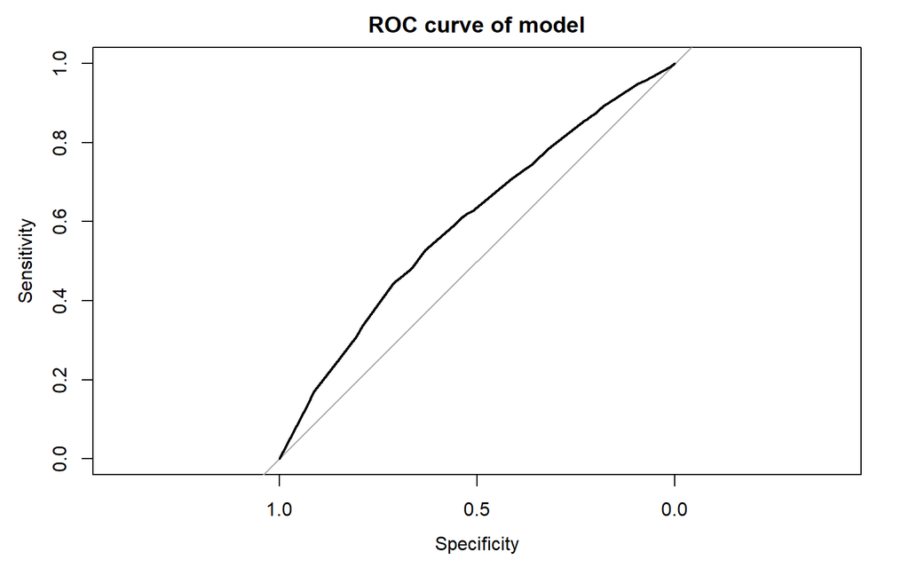

```
##   Type MaturitySize Gender Vaccinated   fit se.fit residual.scale    UL    LL
## 1    1            3      2          1 0.734 0.0847              1 0.711 0.638
##   PredictedProb
## 1         0.676
```

# SMART QUESTION: Does animal profile influence the adoption speed significantly, and what is the best model (Logistic Regression, Knn) when considering these variables?

We research this question because although all pets are cute, there are still some pets are not popular, so we make this model to see what influence the AdoptionSpeed, and see how we can improve it, or let the website of adoption to make some activities to show the cute aspect of the relative not popular pets to adopters.

Firstly, we do some feature selection.

## Feature Selection

##### Exhaustive search

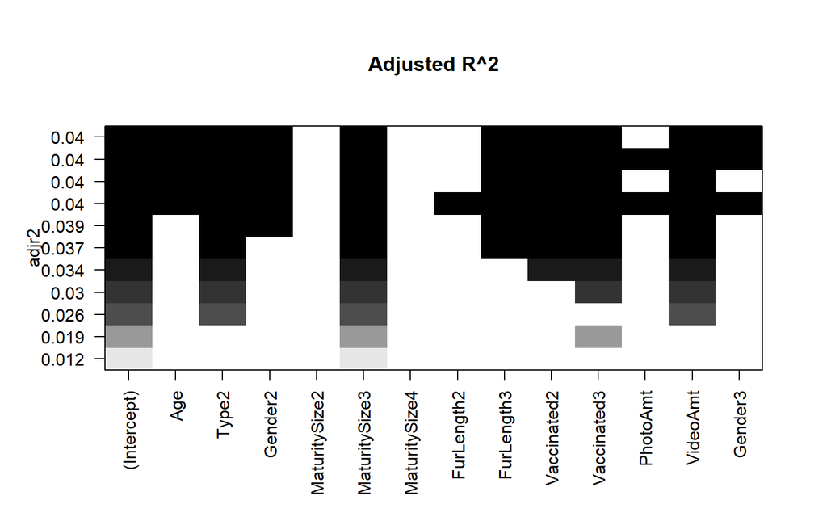

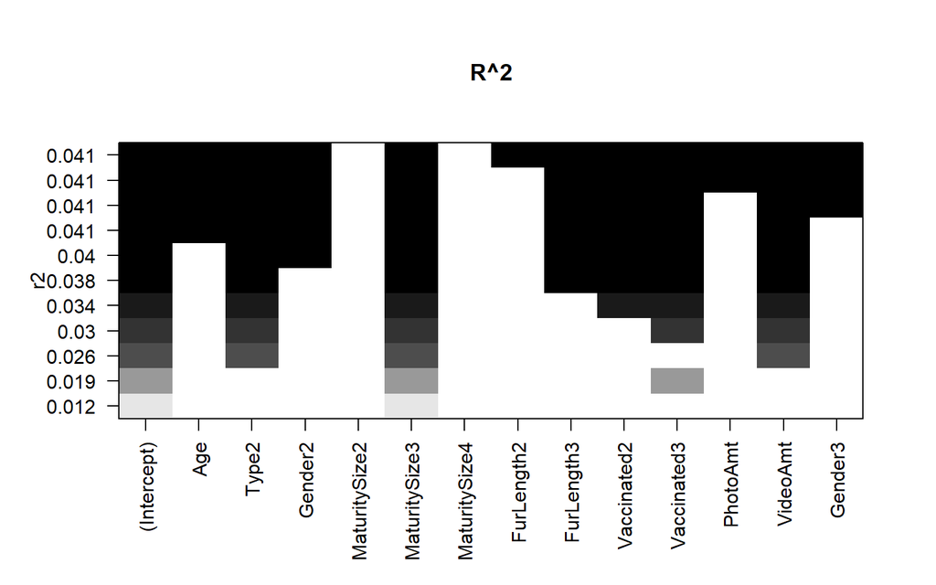

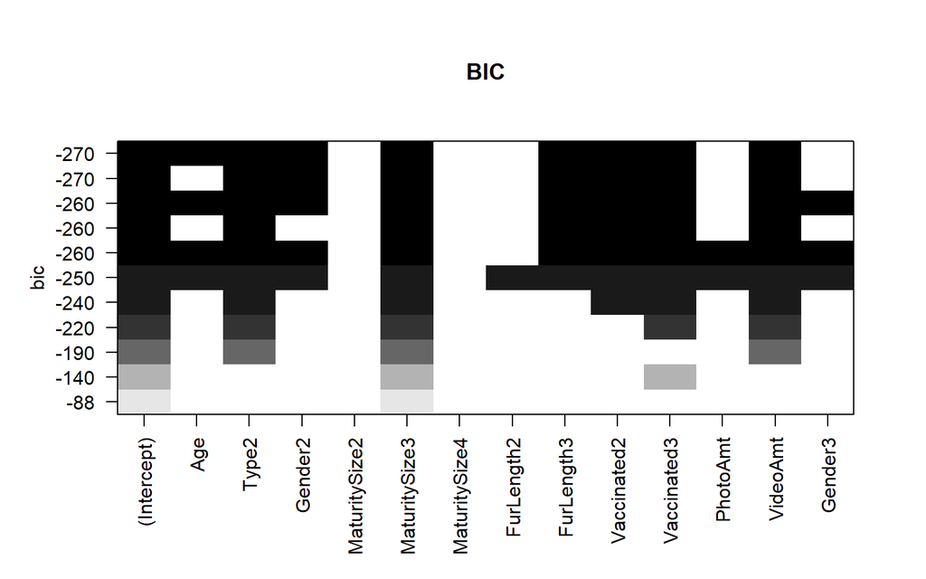

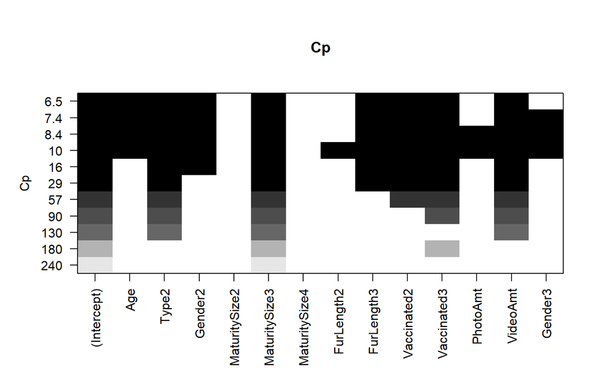

Doing feature selection again.

result of bestglm using AIC

| Age | Type | Gender | MaturitySize | FurLength | Vaccinated | PhotoAmt | VideoAmt | Criterion |
| --- | --- | --- | --- | --- | --- | --- | --- | --- |
| TRUE | TRUE | TRUE | TRUE | TRUE | TRUE | TRUE | FALSE | 10387 |
| TRUE | TRUE | TRUE | TRUE | TRUE | TRUE | TRUE | TRUE | 10388 |
| FALSE | TRUE | TRUE | TRUE | TRUE | TRUE | TRUE | FALSE | 10396 |
| FALSE | TRUE | TRUE | TRUE | TRUE | TRUE | TRUE | TRUE | 10397 |
| TRUE | TRUE | FALSE | TRUE | TRUE | TRUE | TRUE | FALSE | 10400 |

The result of bestglm in AIC is remove VideoAmt. As a result, we put all the variables into the logistic regression first to see whether they are all statistical significant.

## Logistic Regression

|  | Estimate | Std. Error | z value | Pr(>\|z\|) |
| --- | --- | --- | --- | --- |
| (Intercept) | 0.4690 | 0.0828 | 5.662 | 0.0000 |
| Age | 0.0048 | 0.0015 | 3.181 | 0.0015 |
| Type2 | -0.2858 | 0.0505 | -5.653 | 0.0000 |
| Gender2 | 0.1918 | 0.0476 | 4.029 | 0.0001 |
| MaturitySize2 | 0.4552 | 0.0575 | 7.917 | 0.0000 |
| MaturitySize3 | -0.0151 | 0.0916 | -0.165 | 0.8687 |
| MaturitySize4 | 0.2450 | 0.4152 | 0.590 | 0.5550 |
| FurLength2 | -0.2822 | 0.0504 | -5.598 | 0.0000 |
| FurLength3 | -0.6886 | 0.0932 | -7.386 | 0.0000 |
| Vaccinated2 | -0.3074 | 0.0550 | -5.585 | 0.0000 |
| Vaccinated3 | -0.0844 | 0.0777 | -1.086 | 0.2774 |
| PhotoAmt | 0.0666 | 0.0085 | 7.836 | 0.0000 |

From the model of glm, I know that videoAmt is not statistically significant, so I remove this variable from the model. Let us do some model evaluation to see if the model is good or not.

Confusion matrix from Logit Model

|  | Predicted 0 | Predicted 1 | Total |
| --- | --- | --- | --- |
| Actual 0 | 240 | 2530 | 2770 |
| Actual 1 | 207 | 5508 | 5715 |
| Total | 447 | 8038 | 8485 |

##### Hosmer and Lemeshow test

```
##
##  Hosmer and Lemeshow goodness of fit (GOF) test
##
## data:  dataTGMFV$AdoptionSpeed, fitted(petFeaturetableAll)
## X-squared = 8485, df = 8, p-value <2e-16
```

The p-value of 0 is relatively small. Small p-values mean that the model is a poor fit. And the next evaluation is AUC/ROC.

##### AUC/ROC

```
## Area under the curve: 0.621
```

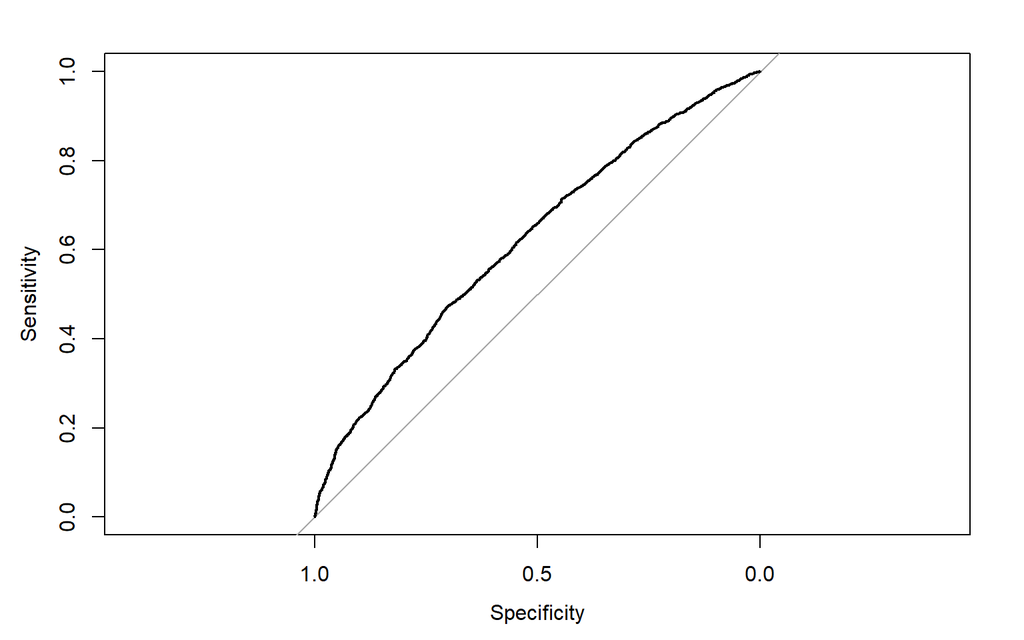

The result of AUC/ROC show that this is not a very good model Area under the curve: 0.621(less than 0.8). After looking at AUC/ROC, let us try McFadden.

##### McFadden

```
##       llh   llhNull        G2  McFadden      r2ML      r2CU
## -5.18e+03 -5.36e+03  3.56e+02  3.32e-02  4.10e-02  5.72e-02
```

With the McFadden value of 0.033, which is analogous to the coefficient of determination $R^2$, only about 0.033 of the variations in y is explained by the explanatory variables in the model.

## KNN

Model: k ~ Total.Accuracy

|  | k | Total.Accuracy |
| --- | --- | --- |
| 1 | 3 | 0.620 |
| 3 | 5 | 0.639 |
| 5 | 7 | 0.641 |
| 7 | 9 | 0.644 |
| 9 | 11 | 0.651 |
| 11 | 13 | 0.650 |
| 13 | 15 | 0.655 |
| 15 | 17 | 0.663 |
| 17 | 19 | 0.661 |
| 19 | 21 | 0.655 |

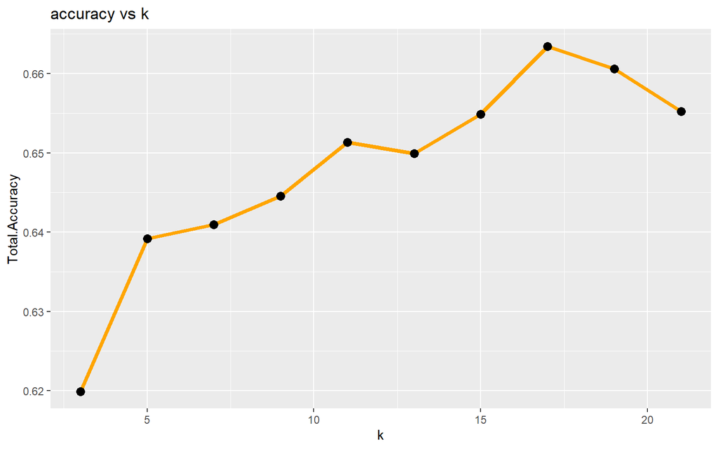

The best KNN is 17, so let us see the confusion matrix.

```
##
##
##    Cell Contents
## |-------------------------|
## |                       N |
## |           N / Row Total |
## |           N / Col Total |
## |         N / Table Total |
## |-------------------------|
##
##
## Total Observations in Table:  2802
##
##
##                | pet_pred
## pet.testLabels |         0 |         1 | Row Total |
## ---------------|-----------|-----------|-----------|
##              0 |       172 |       719 |       891 |
##                |     0.193 |     0.807 |     0.318 |
##                |     0.449 |     0.297 |           |
##                |     0.061 |     0.257 |           |
## ---------------|-----------|-----------|-----------|
##              1 |       211 |      1700 |      1911 |
##                |     0.110 |     0.890 |     0.682 |
##                |     0.551 |     0.703 |           |
##                |     0.075 |     0.607 |           |
## ---------------|-----------|-----------|-----------|
##   Column Total |       383 |      2419 |      2802 |
##                |     0.137 |     0.863 |           |
## ---------------|-----------|-----------|-----------|
##
##
```

Accuracy = 0.668.  
Precision = 0.449.  
Recall rate = 0.193.  
Specificity = 0.89.  
F1 score = 0.27.  
Accuracy = 0.668,so this model also looks not good enough.

As a result, we need more variables and data to predict `AdoptionSpeed`.

# SMART QUESTION: Can the type of animal be classified from the adoption profile?

The next question we wanted to answer switched our attention to the type of animal profile. We determined that we couldn’t predict the adoption speed effectively with classification models. So we thought that we would take a different approach to determining patterns in the adoption profiles. If a classification model was able to predict the type of animal from the adoption profile then it would suggest a pattern in either the animals themselves, or the way the profiles were written. Either possibility leads to more insight about the profiles and possible interventions to ensure the maximum animals are adoptopted into loving homes.

Because this is a binary classification problem we decided to use a logistic regression model and a K nearest neighbors model. Beginning with the logistic model, we ran feature selection to determine what features we should include.

The results of the feature selection are as follows.

```
##    Age Gender MaturitySize FurLength Vaccinated PhotoAmt VideoAmt AdoptionSpeed
## 1 TRUE   TRUE         TRUE      TRUE       TRUE     TRUE    FALSE          TRUE
```

The features that were selected using the `AIC` criteria and the exhaustive method are every feature except for `VideoAmt`. We can now make that model and test it against the animal type. The results of this model are as follows.

Logistic Regression : Type ~ age+gender+size+fur+vaccinated+AdoptSpd+photos

|  | Estimate | Std. Error | z value | Pr(>\|z\|) |
| --- | --- | --- | --- | --- |
| (Intercept) | 0.2594 | 0.0822 | 3.154 | 0.0016 |
| Age | -0.0179 | 0.0018 | -10.212 | 0.0000 |
| Gender2 | -0.1801 | 0.0473 | -3.808 | 0.0001 |
| MaturitySize2 | -0.9701 | 0.0589 | -16.464 | 0.0000 |
| MaturitySize3 | -0.7066 | 0.0950 | -7.440 | 0.0000 |
| MaturitySize4 | -0.9954 | 0.4609 | -2.160 | 0.0308 |
| FurLength2 | -0.1634 | 0.0501 | -3.257 | 0.0011 |
| FurLength3 | 0.5550 | 0.0978 | 5.677 | 0.0000 |
| Vaccinated2 | 0.8690 | 0.0528 | 16.446 | 0.0000 |
| Vaccinated3 | -0.1552 | 0.0794 | -1.955 | 0.0506 |
| AdoptionSpeed.L | -0.4891 | 0.0867 | -5.640 | 0.0000 |
| AdoptionSpeed.Q | 0.0333 | 0.0698 | 0.477 | 0.6336 |
| AdoptionSpeed.C | -0.0480 | 0.0479 | -1.002 | 0.3165 |
| PhotoAmt | 0.0566 | 0.0074 | 7.620 | 0.0000 |

Type Confusion matrix from Logit Model

|  | Predicted 1 | Predicted 2 | Total |
| --- | --- | --- | --- |
| Actual 1 | 3512 | 1242 | 4754 |
| Actual 2 | 1694 | 2037 | 3731 |
| Total | 5206 | 3279 | 8485 |

Accuracy: 0.654  
Precision: 0.675  
Recall: 0.739  
F1: 0.705

These numbers aren’t terrible, but let’s look at other metrics as well.

We can look at the Hoslem and Lemeshow Goodness of Fit test next.

**H0**: The model is a good fit for our dependent variable  
**H1**: The model is a bad fir for our dependent variable

```
##
##  Hosmer and Lemeshow goodness of fit (GOF) test
##
## data:  datclean$y, fitted(typeLogit)
## X-squared = 8485, df = 8, p-value <2e-16
```

With a p_value of 0 we can reject the null hypothesis that this model was a good fit for our dependent variable of animal type. In order to confirm this finding we wanted to look at the Receiver Operator Curve of this model. This plot shows the true positive rate against the false positive rate. By plotting the model in this way we can see how well above chance the model preforms.

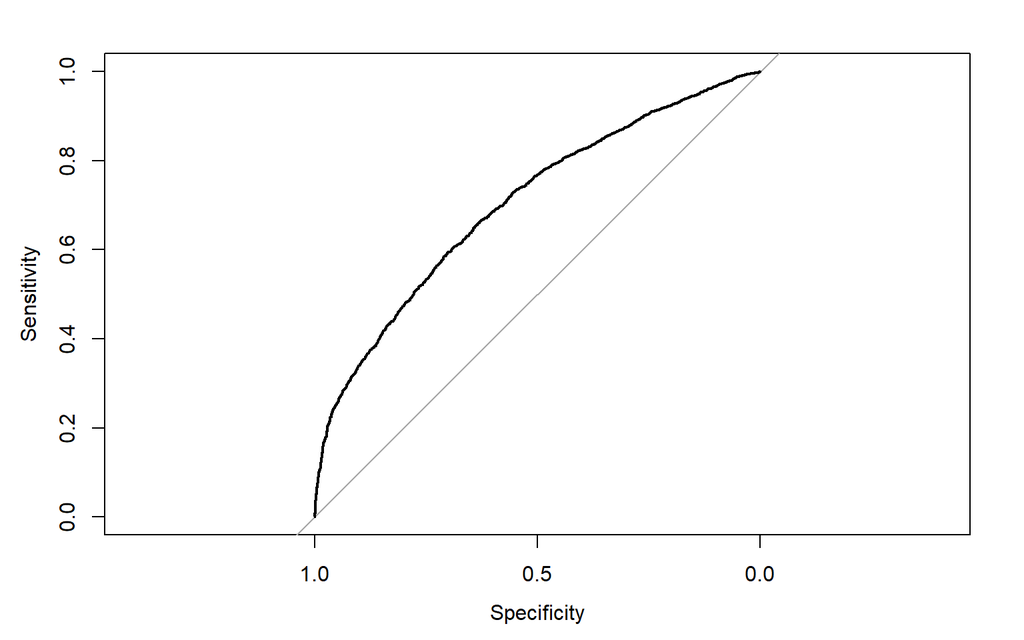

We can see by looking at this plot that the model is not very effective. While it is above chance, we ideally want to see a more defined box-shape of the curve which would suggest that it is able to accurately predict the type of animal. The area under this curve confirms that the model is not great. With our AUC = 0.702, this is below the threshold of 0.8 that we are looking for to consider a model an effective classifier.

The final metric we can use to confirm the state of our logistic model is the McFadden score. This is a proxy for an $R^2$ value.

```
## fitting null model for pseudo-r2
```

With a McFadden score of 0.0972 we can say that only 9.72% of the variance in Type is explained by this model.

After looking at all these metrics we have confirmed that this model is not adept at classifying type based on the adoption profile of the animal. Given this, we decided to move on to the KNN model in the hopes that this model would be more effective.

The first step to use this model is cleaning the dataset. First, the numeric variables `Age`, `Photo Amount` and `Video Amount` are scaled to center them. Then all the factor level variables are returned to numeric variables for the model.

In order to determine the optimal K value for the KNN model we ran through values 3-20 and chose the K with the highest total accuracy.

The K value that was determined to be the best for this model was k = 18 with a total accuracy of 0.68.

To make sure that we’re getting the best possible model we tried one more KNN model before looking closer at the results. We removed `Video Amount` from the feature list since it was removed in the logistic regression model. We did the same run through of K values from 3-20.

The K value that was determined to be the best for this model was k = 20 with a total accuracy of 0.683. This accuracy is very slightly better than the previous model, so we will continue with this model going forward.

Taking a closer look at this second model we can pull out a number of statistics.

```
##
##
##    Cell Contents
## |-------------------------|
## |                       N |
## |           N / Row Total |
## |           N / Col Total |
## |         N / Table Total |
## |-------------------------|
##
##
## Total Observations in Table:  2544
##
##
##              | tpred
##    testLabel |         1 |         2 | Row Total |
## -------------|-----------|-----------|-----------|
##            1 |      1173 |       279 |      1452 |
##              |     0.808 |     0.192 |     0.571 |
##              |     0.691 |     0.330 |           |
##              |     0.461 |     0.110 |           |
## -------------|-----------|-----------|-----------|
##            2 |       525 |       567 |      1092 |
##              |     0.481 |     0.519 |     0.429 |
##              |     0.309 |     0.670 |           |
##              |     0.206 |     0.223 |           |
## -------------|-----------|-----------|-----------|
## Column Total |      1698 |       846 |      2544 |
##              |     0.667 |     0.333 |           |
## -------------|-----------|-----------|-----------|
##
##
```

Accuracy: 0.684  
Precision: 0.691  
Recall: 0.808  
F1: 0.745

All of these numbers are higher than our Logistic regression model so we can confirm that this model is slightly better at decoding type of animal from the adoption profile. While the model is better than chance, it’s still not incredibly effective. This suggests that while there might be some discernible pattern to the profiles of the dogs and cats put on petfinder, it is not drastic enough that the model is incredibly accurate.

That being said, future studies should look into this pattern to see what the differences are specifically and whether or not they have an effect on adoption speed.

# SMART Question: Can puppies/kittens be identified based on their adoption profile?

## Objective

A common problem at animal shelters is difficulty in accurately determining the age of the pet. Many families/prospective pet adopters have specific preferences for younger or older animals. Determining if the other data can generate an accurate prediction of whether or not an animal is very young or not seem like a reasonable first step in determining if age can at all be predicted using this data. As 55.05 percent of the pets are young, if there is any hope is predicting age beginning with a relatively balanced output is valuable.

To answer the SMART question, let us consider the general problem. There is a categorical dependent variable, and a mixture of numerical and categorical independent variables. A Logistic Regression makes a great deal of sense in this situation. A classification-tree model is an option if left unsatisfied with the logistic model’s outcome.

## Logistic Model

- Logistic Model Feature Selection

```
##   Type Gender MaturitySize FurLength Vaccinated PhotoAmt VideoAmt AdoptionSpeed
## 1 TRUE   TRUE         TRUE      TRUE       TRUE     TRUE     TRUE          TRUE
```

Starting off with a full model, excluding Age as it would be collinear to puppy. Feature Selection indicates all variables should be kept.

Logistic Regression : Puppy ~ All variables

|  | Estimate | Std. Error | z value | Pr(>\|z\|) |
| --- | --- | --- | --- | --- |
| (Intercept) | -0.6108 | 0.0833 | -7.331 | 0.0000 |
| Type2 | -0.5404 | 0.0543 | -9.945 | 0.0000 |
| Gender2 | 0.1196 | 0.0497 | 2.408 | 0.0160 |
| MaturitySize2 | 0.2332 | 0.0605 | 3.855 | 0.0001 |
| MaturitySize3 | -0.8213 | 0.1030 | -7.971 | 0.0000 |
| MaturitySize4 | -1.3317 | 0.5609 | -2.374 | 0.0176 |
| FurLength2 | -0.1142 | 0.0520 | -2.196 | 0.0281 |
| FurLength3 | -1.2641 | 0.1100 | -11.493 | 0.0000 |
| Vaccinated2 | 1.8752 | 0.0567 | 33.101 | 0.0000 |
| Vaccinated3 | 0.2664 | 0.0752 | 3.542 | 0.0004 |
| PhotoAmt | 0.0382 | 0.0081 | 4.717 | 0.0000 |
| VideoAmt | 0.1500 | 0.0794 | 1.889 | 0.0590 |
| AdoptionSpeed.L | -0.1447 | 0.0897 | -1.612 | 0.1069 |
| AdoptionSpeed.Q | -0.3056 | 0.0722 | -4.231 | 0.0000 |
| AdoptionSpeed.C | 0.0230 | 0.0507 | 0.454 | 0.6502 |

### Logistic Model Evaluation

#### Confusion Matrix for Logistic Model

Confusion matrix from Logit Model

|  | Predicted 0 | Predicted 1 | Total |
| --- | --- | --- | --- |
| Actual 0 | 2730 | 1084 | 3814 |
| Actual 1 | 1493 | 3178 | 4671 |
| Total | 4223 | 4262 | 8485 |

Accuracy: 0.696  
Precision: 0.646  
Recall: 0.716  
F1: 0.679

Not the worst confusion matrix ever seen. Model over predicts old dogs and under predicts puppies. Additional tests will be needed to determine model quality.

#### Hosmer and Lemeshow goodness of fit (GOF) test

**H0** = Model predictions are not statistically different to actual values. **H1** = Model predictions are statistically different than actual values.

-The p-value of the test is 0, which is very low. The null hypothesis is rejected, and the alternative hypothesis accepted. According to this test the generated model is not a good fit. Based on this finding, as well as the values generated from the confusion matrix, confidence in the model is declining.

#### Reciever-Operator Curve

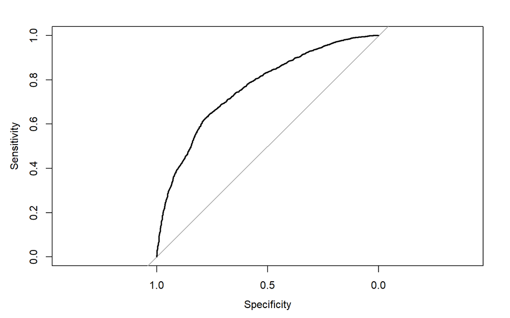

The McFadden score of 10% is pretty low. As the McFadden score is essentially a pseudo $R^2$ value for logistic models, only 10% of the variation in the data is explained by the model.

Let’s see if a classification tree can give a better score. It is possible the logistic model is just inappropriate for this dataset.